# Final Project Part 3: Classification

Thomas Brusilovsky

2022-12-11

## Load packages

```r
library(tidyverse)
library(caret)
```

The code chunk below reads in the final project data.

```r
df <- readr::read_csv("fall2022_finalproject.csv", col_names = TRUE)
```

Next, we create a number of other relevant features

```r
df_new_cols <- df %>% mutate(x5 = (1 - (x1 + x2 + x3 + x4))) %>%
  mutate(w = x2 / (x3 + x4)) %>%
  mutate(z = (x1 + x2) / (x4 + x5)) %>%
  mutate(t = v1*v2) %>%
  mutate(binary_outcome = as.factor(case_when(output < .33  ~ 'True', output >=.33 ~ 'False')))
```

Now, before we can train our models we need to center and standardize our data.

```r
df_derived <- df_new_cols %>%
  purrr::keep(is.numeric) %>%
  scale() %>%
  bind_cols(df_new_cols %>% purrr::discard(is.numeric)) %>%
  select(all_of(names(df_new_cols)))
df_derived$binary_outcome = df_new_cols$binary_outcome
```

```r
df_derived %>% summary()
```

```
##        x1                 x2                x3                 x4
##  Min.   :-1.72358   Min.   :-1.5317   Min.   :-2.10525   Min.   :-1.9900
##  1st Qu.:-0.79161   1st Qu.:-0.9668   1st Qu.:-0.66845   1st Qu.:-0.7098
##  Median : 0.08819   Median : 0.1092   Median : 0.00712   Median : 0.1012
##  Mean   : 0.00000   Mean   : 0.0000   Mean   : 0.00000   Mean   : 0.0000
##  3rd Qu.: 0.57624   3rd Qu.: 0.7659   3rd Qu.: 0.65660   3rd Qu.: 0.7276
##  Max.   : 2.26171   Max.   : 2.7806   Max.   : 2.00544   Max.   : 1.8722
##        v1                 v2                 v3                 v4
##  Min.   :-1.87874   Min.   :-1.82989   Min.   :-1.84248   Min.   :-2.0207
##  1st Qu.:-0.64538   1st Qu.:-0.61769   1st Qu.:-0.65526   1st Qu.:-0.8101
##  Median : 0.02132   Median : 0.04372   Median : 0.02533   Median :-0.0089
##  Mean   : 0.00000   Mean   : 0.00000   Mean   : 0.00000   Mean   : 0.0000
##  3rd Qu.: 0.65548   3rd Qu.: 0.66339   3rd Qu.: 0.65379   3rd Qu.: 0.8049
##  Max.   : 1.87066   Max.   : 1.88398   Max.   : 1.85922   Max.   : 2.0855
##        v5               m                 output              x5
##  Min.   :-1.6744   Length:1252        Min.   :-1.6772   Min.   :-1.3512
##  1st Qu.:-0.9793   Class :character   1st Qu.:-0.8940   1st Qu.:-0.7512
##  Median : 0.1798   Mode  :character   Median :-0.1525   Median :-0.3858
##  Mean   : 0.0000                      Mean   : 0.0000   Mean   : 0.0000
##  3rd Qu.: 0.9890                      3rd Qu.: 0.9979   3rd Qu.: 0.5379
##  Max.   : 1.1807                      Max.   : 1.4971   Max.   : 3.5060
##        w                  z                  t            binary_outcome
##  Min.   :-1.78840   Min.   :-1.46178   Min.   :-1.21451   False:816
##  1st Qu.:-0.84523   1st Qu.:-0.89122   1st Qu.:-0.83296   True :436
##  Median : 0.04584   Median :-0.07615   Median :-0.08334
##  Mean   : 0.00000   Mean   : 0.00000   Mean   : 0.00000
##  3rd Qu.: 0.84833   3rd Qu.: 0.72892   3rd Qu.: 0.42145
##  Max.   : 1.62811   Max.   : 2.17530   Max.   : 3.63536
```

## Linear Models

Before moving on to more advanced methods, we will use a number of linear models to establish a baseline. We will use the glm() function to fit nine such models.

# Training the models

Model 1: All linear additive features of the base features

```r
lin_mod1 <-glm(binary_outcome ~ x1 + x2 + x3 + x4 + v1 + v2 + v3 + v4 + v5, data = df_derived, family = 'binomial')
```

Model 2: Interaction of the categorical input with all continuous inputs in the base features

```r
lin_mod2 <-glm(binary_outcome ~ m*(x1 + x2 + x3 + x4 + v1 + v2 + v3 + v4 + v5), data = df_derived, family = 'binomial')
```

Model 3: All pair-wise interactions of the continuous inputs in the base features

```r
lin_mod3 <- glm(binary_outcome ~ (x1 + x2 + x3 + x4 + v1 + v2 + v3 + v4 + v5) * (x1 + x2 + x3 + x4 + v1 + v2 + v3 + v4 + v5),data = df_derived, family = 'binomial')
```

Model 4: All linear additive features

```r
#x5 is not included as it is simply a combination of x1-4
lin_mod4 <- glm(binary_outcome ~ . - m - output  -x5,data = df_derived, family = 'binomial')
```

Model 5: Interaction of the categorical input with all continuous features

```r
#x5 is not included as it is simply a combination of x1-4
lin_mod5 <- glm(binary_outcome ~ m* (. - m - output  -x5),data = df_derived, family = 'binomial')
```

Model 6: Pair-wise interactions between the continuous features

```r
#x5 is not included as it is simply a combination of x1-4, v1:v2 is excluded as t = v1:v2
lin_mod6 <- glm(binary_outcome ~  (. - m - output -x5) * (. - m - output -x5) - v1:v2,data = df_derived, family = 'binomial')
```

Model 7: All linear additive and quadratic features

```r
lin_mod7 <- glm(binary_outcome ~ x1 + x2 + x3 + x4 + v1 + v2 + v3 + v4 + v5 + w + z + t + I(x1^2) + I(x2^2) + I(x3^2) + I(x4^2) + I(v1^2) + I(v2^2) + I(v3^2) + I(v4^2) + I(v5^2) + I(w^2) + I(z^2) + I(t^2)  , data = df_derived, family = 'binomial')
```

Model 8: Sin of all continuous features in the base set

```r
lin_mod8 <- glm(binary_outcome ~ sin(x1) + sin(x2) + sin(x3) + sin(x4) + sin(v1) + sin(v2) + sin(v3) + sin(v4) + sin(v5), data = df_derived , family = 'binomial')
```

Model 9: Interaction between some features from the base set

```r
#features are chosen from those found to be correlated during the exploration.
lin_mod9 <- glm(binary_outcome ~ x1*x2 + x1*x3 + x2*x3 + x3*x4 + x2*v4 + x1*v5 + x2*v5, data = df_derived, family = 'binomial')
```

#Assessing the models

Using AIC as a metric, we can identify the best performing model. We want to minimize the AIC, so the model with the lowest value is the best one.

```r
summary(lin_mod1)$aic
```

```
## [1] 1578.735
```

```r
summary(lin_mod2)$aic
```

```
## [1] 1616.893
```

```r
summary(lin_mod3)$aic
```

```
## [1] 1576.354
```

```r
summary(lin_mod4)$aic
```

```
## [1] 1359.456
```

```r
summary(lin_mod5)$aic
```

```
## [1] 1407.123
```

```r
summary(lin_mod6)$aic
```

```
## [1] 1174.439
```

```r
summary(lin_mod7)$aic
```

```
## [1] 1161.75
```

```r
summary(lin_mod8)$aic
```

```
## [1] 1571.664
```

```r
summary(lin_mod9)$aic
```

```
## [1] 1564.867
```

Looking at the AIC values, we find the best three models in order from best to worst to be model 7, model 6, and model 4.

Now, let us look at the coefficient summaries of each model and visualize them.

# Model 7

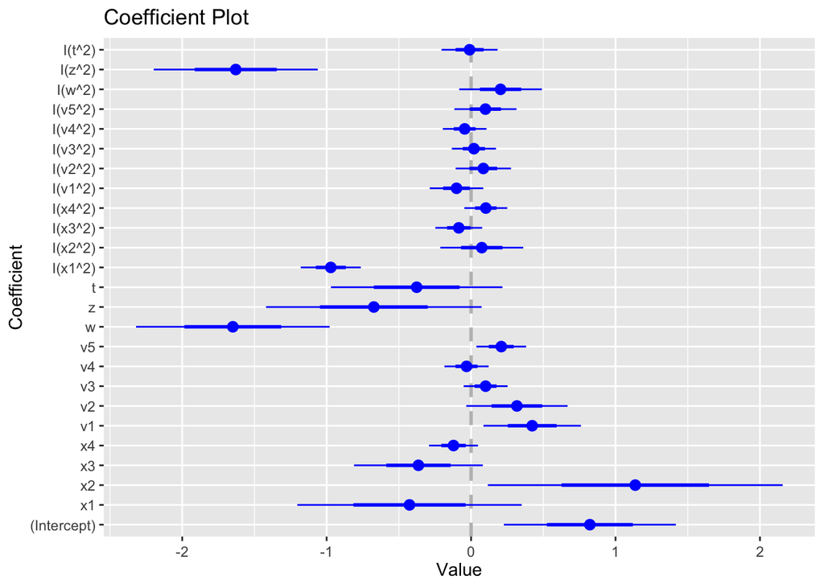

```r
coefplot::coefplot(lin_mod7)
```

```r
summary(lin_mod7)
```

```
##
## Call:
## glm(formula = binary_outcome ~ x1 + x2 + x3 + x4 + v1 + v2 +
##     v3 + v4 + v5 + w + z + t + I(x1^2) + I(x2^2) + I(x3^2) +
##     I(x4^2) + I(v1^2) + I(v2^2) + I(v3^2) + I(v4^2) + I(v5^2) +
##     I(w^2) + I(z^2) + I(t^2), family = "binomial", data = df_derived)
##
## Deviance Residuals:
##     Min       1Q   Median       3Q      Max
## -2.0621  -0.7158  -0.1946   0.8028   3.1350
##
## Coefficients:
##             Estimate Std. Error z value Pr(>|z|)
## (Intercept)  0.82232    0.29772   2.762  0.00574 **
## x1          -0.42634    0.38826  -1.098  0.27217
## x2           1.13663    0.51039   2.227  0.02595 *
## x3          -0.36454    0.22281  -1.636  0.10181
## x4          -0.12177    0.08475  -1.437  0.15079
## v1           0.42304    0.16871   2.507  0.01216 *
## v2           0.31718    0.17533   1.809  0.07045 .
## v3           0.10059    0.07601   1.323  0.18568
## v4          -0.03155    0.07639  -0.413  0.67964
## v5           0.20903    0.08613   2.427  0.01522 *
## w           -1.64947    0.33500  -4.924 8.49e-07 ***
## z           -0.67336    0.37312  -1.805  0.07113 .
## t           -0.37662    0.29688  -1.269  0.20458
## I(x1^2)     -0.97135    0.10387  -9.352  < 2e-16 ***
## I(x2^2)      0.07404    0.14342   0.516  0.60570
## I(x3^2)     -0.08527    0.08103  -1.052  0.29261
## I(x4^2)      0.10197    0.07438   1.371  0.17039
## I(v1^2)     -0.10084    0.09277  -1.087  0.27704
## I(v2^2)      0.08475    0.09575   0.885  0.37610
## I(v3^2)      0.01957    0.07654   0.256  0.79815
## I(v4^2)     -0.04433    0.07559  -0.586  0.55755
## I(v5^2)      0.09936    0.10760   0.923  0.35580
## I(w^2)       0.20388    0.14314   1.424  0.15434
## I(z^2)      -1.62929    0.28392  -5.739 9.55e-09 ***
## I(t^2)      -0.01045    0.09699  -0.108  0.91419
## ---
## Signif. codes:  0 '***' 0.001 '**' 0.01 '*' 0.05 '.' 0.1 ' ' 1
##
## (Dispersion parameter for binomial family taken to be 1)
##
##     Null deviance: 1618.5  on 1251  degrees of freedom
## Residual deviance: 1111.7  on 1227  degrees of freedom
## AIC: 1161.7
##
## Number of Fisher Scoring iterations: 6
```

# Model 6

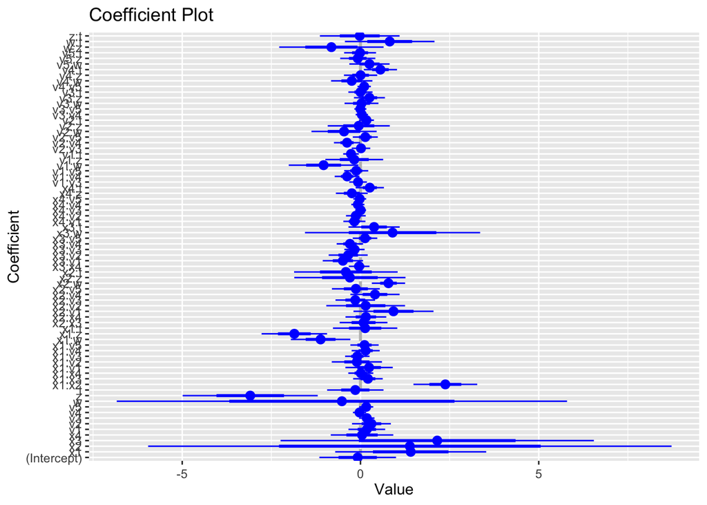

```r
coefplot::coefplot(lin_mod6)
```

```r
summary(lin_mod6)
```

```
##
## Call:
## glm(formula = binary_outcome ~ (. - m - output - x5) * (. - m -
##     output - x5) - v1:v2, family = "binomial", data = df_derived)
##
## Deviance Residuals:
##     Min       1Q   Median       3Q      Max
## -2.5385  -0.6265  -0.1741   0.6964   3.5181
##
## Coefficients: (2 not defined because of singularities)
##               Estimate Std. Error z value Pr(>|z|)
## (Intercept) -0.0778373  0.5372281  -0.145 0.884800
## x1           1.4090327  1.0588665   1.331 0.183288
## x2           1.3850052  3.6705482   0.377 0.705929
## x3           2.1529952  2.1970967   0.980 0.327122
## x4           0.0436927  0.4383631   0.100 0.920604
## v1           0.1784461  0.2574266   0.693 0.488189
## v2           0.3080012  0.2723485   1.131 0.258094
## v3           0.1776932  0.1080404   1.645 0.100034
## v4          -0.0267830  0.0927037  -0.289 0.772650
## v5           0.1610871  0.0987153   1.632 0.102714
## w           -0.5208695  3.1578271  -0.165 0.868987
## z           -3.0916295  0.9469955  -3.265 0.001096 **
## t           -0.1446463  0.3954341  -0.366 0.714521
## x1:x2        2.3804377  0.4473431   5.321 1.03e-07 ***
## x1:x3        0.2093417  0.2073818   1.009 0.312758
## x1:x4        0.0097279  0.1753250   0.055 0.955752
## x1:v1        0.2412610  0.3324267   0.726 0.467988
## x1:v2       -0.1012534  0.3521637  -0.288 0.773716
## x1:v3       -0.0884877  0.1716419  -0.516 0.606178
## x1:v4        0.1453618  0.1967497   0.739 0.460019
## x1:v5        0.1133281  0.1982067   0.572 0.567480
## x1:w        -1.1183884  0.4173727  -2.680 0.007371 **
## x1:z        -1.8549650  0.4589269  -4.042 5.30e-05 ***
## x1:t         0.1307112  0.4513759   0.290 0.772135
## x2:x3        0.0865046  0.3352232   0.258 0.796368
## x2:x4        0.1518944  0.2860793   0.531 0.595452
## x2:v1        0.9259538  0.5611628   1.650 0.098930 .
## x2:v2        0.1459010  0.5520275   0.264 0.791549
## x2:v3       -0.1449990  0.2776341  -0.522 0.601485
```

[output cut: 44 more lines]

```
## v5:z        -0.0757524  0.2464848  -0.307 0.758591
## v5:t        -0.0108222  0.2235342  -0.048 0.961386
## w:z         -0.8155473  0.7321148  -1.114 0.265296
## w:t          0.8199406  0.6285160   1.305 0.192041
## z:t         -0.0204692  0.5586004  -0.037 0.970769
## ---
## Signif. codes:  0 '***' 0.001 '**' 0.01 '*' 0.05 '.' 0.1 ' ' 1
##
## (Dispersion parameter for binomial family taken to be 1)
##
##     Null deviance: 1618.5  on 1251  degrees of freedom
## Residual deviance: 1022.4  on 1176  degrees of freedom
## AIC: 1174.4
##
## Number of Fisher Scoring iterations: 6
```

# Model 4

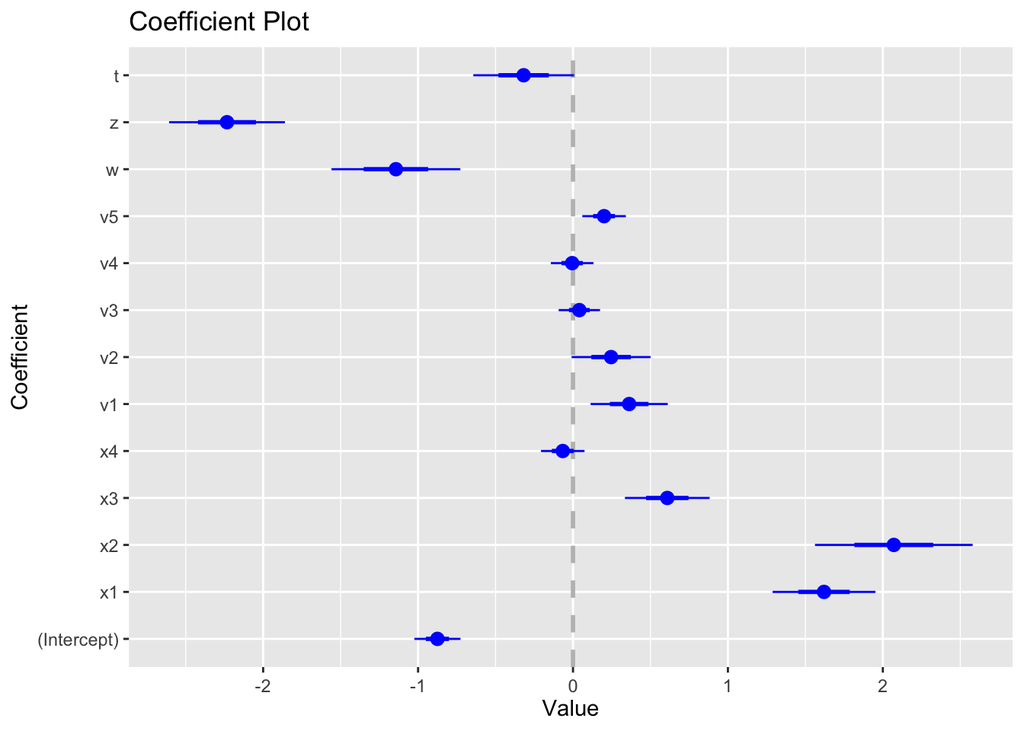

```r
coefplot::coefplot(lin_mod4)
```

```r
summary(lin_mod4)
```

```
##
## Call:
## glm(formula = binary_outcome ~ . - m - output - x5, family = "binomial",
##     data = df_derived)
##
## Deviance Residuals:
##     Min       1Q   Median       3Q      Max
## -1.9611  -0.8860  -0.4278   1.0243   2.3800
##
## Coefficients:
##              Estimate Std. Error z value Pr(>|z|)
## (Intercept) -0.875130   0.074515 -11.744  < 2e-16 ***
## x1           1.620259   0.166109   9.754  < 2e-16 ***
## x2           2.070960   0.254501   8.137 4.04e-16 ***
## x3           0.608646   0.136674   4.453 8.46e-06 ***
## x4          -0.066070   0.070222  -0.941  0.34677
## v1           0.362614   0.124550   2.911  0.00360 **
## v2           0.245891   0.127479   1.929  0.05375 .
## v3           0.041006   0.066723   0.615  0.53884
## v4          -0.005459   0.068815  -0.079  0.93677
## v5           0.200702   0.070332   2.854  0.00432 **
## w           -1.143067   0.208103  -5.493 3.96e-08 ***
## z           -2.233431   0.186923 -11.948  < 2e-16 ***
## t           -0.318553   0.162492  -1.960  0.04995 *
## ---
## Signif. codes:  0 '***' 0.001 '**' 0.01 '*' 0.05 '.' 0.1 ' ' 1
##
## (Dispersion parameter for binomial family taken to be 1)
##
##     Null deviance: 1618.5  on 1251  degrees of freedom
## Residual deviance: 1333.5  on 1239  degrees of freedom
## AIC: 1359.5
##
## Number of Fisher Scoring iterations: 5
```

# Comparison and important inputs

Looking at the three models, we can see that model 6 has the most coefficients while model 4 has the fewest. In each model, a number of the inputs are not statistically significant while other inputs are clearly more important than others. The models have relatively similar deviance residuals and there AIC scores are relatively close together, though there is a larger gap between the 2nd and 3rd best verse the 1st and 2nd best.

## Bayesian Linear Models

Next, we will consider the uncertainty via Bayesian methods. We will fit models 7 and 4 from the previous part. 7 was our best model so we will fit it, while 4 uses a similar set of features as 7 but without some of the potential noise so it may show some interesting insight into the overall data.

To fit these models, we will use functions from the rstanarm package which we must thus import.

```r
library(rstanarm)
bays_mod7 <- stan_glm(binary_outcome ~ x1 + x2 + x3 + x4 + v1 + v2 + v3 + v4 + v5 + w + z + t + I(x1^2) + I(x2^2) + I(x3^2) + I(x4^2) + I(v1^2) + I(v2^2) + I(v3^2) + I(v4^2) + I(v5^2) + I(w^2) + I(z^2) + I(t^2)  , data = df_derived,
                      seed = 15217,family = binomial)
bays_mod4 <- stan_glm(binary_outcome ~ x1 + x2 + x3 + x4 + v1 + v2 + v3 + v4 + v5 + w + z + t , data = df_derived,
                      seed = 15217, family = binomial)
```

Now, let us compare the two models by looking at their summaries.

```r
summary(bays_mod7)
```

```
##
## Model Info:
##  function:     stan_glm
##  family:       binomial [logit]
##  formula:      binary_outcome ~ x1 + x2 + x3 + x4 + v1 + v2 + v3 + v4 + v5 +
##     w + z + t + I(x1^2) + I(x2^2) + I(x3^2) + I(x4^2) + I(v1^2) +
##     I(v2^2) + I(v3^2) + I(v4^2) + I(v5^2) + I(w^2) + I(z^2) +
##     I(t^2)
##  algorithm:    sampling
##  sample:       4000 (posterior sample size)
##  priors:       see help('prior_summary')
##  observations: 1252
##  predictors:   25
##
## Estimates:
##               mean   sd   10%   50%   90%
## (Intercept)  0.9    0.3  0.5   0.8   1.2
## x1          -0.4    0.4 -0.9  -0.4   0.1
## x2           1.1    0.5  0.5   1.1   1.8
## x3          -0.3    0.2 -0.6  -0.3  -0.1
## x4          -0.1    0.1 -0.2  -0.1   0.0
## v1           0.4    0.2  0.2   0.4   0.7
## v2           0.3    0.2  0.1   0.3   0.6
## v3           0.1    0.1  0.0   0.1   0.2
## v4           0.0    0.1 -0.1   0.0   0.1
## v5           0.2    0.1  0.1   0.2   0.3
## w           -1.7    0.3 -2.1  -1.6  -1.2
## z           -0.7    0.4 -1.2  -0.7  -0.2
## t           -0.4    0.3 -0.8  -0.4   0.0
## I(x1^2)     -1.0    0.1 -1.1  -1.0  -0.9
## I(x2^2)      0.1    0.1 -0.1   0.1   0.3
## I(x3^2)     -0.1    0.1 -0.2  -0.1   0.0
## I(x4^2)      0.1    0.1  0.0   0.1   0.2
## I(v1^2)     -0.1    0.1 -0.2  -0.1   0.0
## I(v2^2)      0.1    0.1  0.0   0.1   0.2
## I(v3^2)      0.0    0.1 -0.1   0.0   0.1
## I(v4^2)      0.0    0.1 -0.1   0.0   0.1
## I(v5^2)      0.1    0.1  0.0   0.1   0.2
## I(w^2)       0.2    0.1  0.0   0.2   0.4
## I(z^2)      -1.7    0.3 -2.0  -1.7  -1.3
```

[output cut: 24 more lines]

```
## I(x2^2)       0.0  1.0  2589
## I(x3^2)       0.0  1.0  3220
## I(x4^2)       0.0  1.0  4168
## I(v1^2)       0.0  1.0  2964
## I(v2^2)       0.0  1.0  2861
## I(v3^2)       0.0  1.0  4260
## I(v4^2)       0.0  1.0  4971
## I(v5^2)       0.0  1.0  4227
## I(w^2)        0.0  1.0  2767
## I(z^2)        0.0  1.0  1698
## I(t^2)        0.0  1.0  2286
## mean_PPD      0.0  1.0  4460
## log-posterior 0.1  1.0  1464
##
## For each parameter, mcse is Monte Carlo standard error, n_eff is a crude measure of effective sample size, and Rhat is the potential scale reduction factor on split chains (at convergence Rhat=1).
```

```r
summary(bays_mod4)
```

```
##
## Model Info:
##  function:     stan_glm
##  family:       binomial [logit]
##  formula:      binary_outcome ~ x1 + x2 + x3 + x4 + v1 + v2 + v3 + v4 + v5 +
##     w + z + t
##  algorithm:    sampling
##  sample:       4000 (posterior sample size)
##  priors:       see help('prior_summary')
##  observations: 1252
##  predictors:   13
##
## Estimates:
##               mean   sd   10%   50%   90%
## (Intercept) -0.9    0.1 -1.0  -0.9  -0.8
## x1           1.6    0.2  1.4   1.6   1.8
## x2           2.1    0.2  1.8   2.1   2.4
## x3           0.6    0.1  0.4   0.6   0.8
## x4          -0.1    0.1 -0.2  -0.1   0.0
## v1           0.4    0.1  0.2   0.4   0.5
## v2           0.2    0.1  0.1   0.2   0.4
## v3           0.0    0.1  0.0   0.0   0.1
## v4           0.0    0.1 -0.1   0.0   0.1
## v5           0.2    0.1  0.1   0.2   0.3
## w           -1.1    0.2 -1.4  -1.1  -0.9
## z           -2.2    0.2 -2.5  -2.2  -2.0
## t           -0.3    0.2 -0.5  -0.3  -0.1
##
## Fit Diagnostics:
##            mean   sd   10%   50%   90%
## mean_PPD 0.3    0.0  0.3   0.3   0.4
##
## The mean_ppd is the sample average posterior predictive distribution of the outcome variable (for details see help('summary.stanreg')).
##
## MCMC diagnostics
##               mcse Rhat n_eff
## (Intercept)   0.0  1.0  3752
## x1            0.0  1.0  2809
## x2            0.0  1.0  2739
## x3            0.0  1.0  3246
## x4            0.0  1.0  4541
## v1            0.0  1.0  2707
## v2            0.0  1.0  2787
## v3            0.0  1.0  5128
## v4            0.0  1.0  5594
## v5            0.0  1.0  5243
## w             0.0  1.0  2931
## z             0.0  1.0  2722
## t             0.0  1.0  2506
## mean_PPD      0.0  1.0  4384
## log-posterior 0.1  1.0  1732
##
## For each parameter, mcse is Monte Carlo standard error, n_eff is a crude measure of effective sample size, and Rhat is the potential scale reduction factor on split chains (at convergence Rhat=1).
```

Now let us try to compare the two models by looking at their waic values.

```r
bays_mod4$waic <- waic(bays_mod4)
bays_mod7$waic <- waic(bays_mod7)
bays_mod4$waic
```

```
##
## Computed from 4000 by 1252 log-likelihood matrix
##
##           Estimate   SE
## elpd_waic   -679.8 15.7
## p_waic        13.0  0.5
## waic        1359.5 31.5
```

```r
bays_mod7$waic
```

```
##
## Computed from 4000 by 1252 log-likelihood matrix
##
##           Estimate   SE
## elpd_waic   -582.3 19.5
## p_waic        26.8  1.6
## waic        1164.6 38.9
##
## 4 (0.3%) p_waic estimates greater than 0.4. We recommend trying loo instead.
```

# Model 7 Visualization

Having selected model 7 as our best model, let us look further at it. We can visualize the regression coefficient posterior summary statistics to better understand the model.

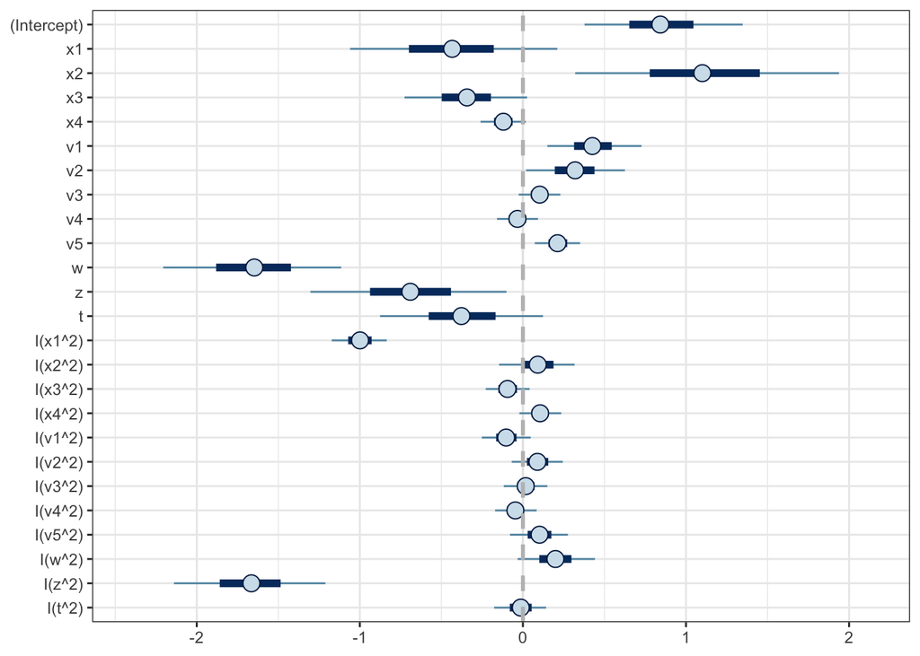

```r
plot(bays_mod7, pars = names(bays_mod7$coefficients)) +
  geom_vline(xintercept = 0, color = "grey", linetype = "dashed", size = 1.0) +
  theme_bw()
```

## GLM Predictions

We will make predictions using the non-Bayesian models 4 and 7. To do this, we must first create a prediction grid to run our models on.

# Model 4

For model 4, the 2 most important inputs are z and x2, thus we will use those to populate our visualization grid.

```r
expand_grid <- expand.grid(x1 = median(df_derived$x1),  #values between 0 and 1
                        x2 = seq(min(df_derived$x2),max(df_derived$x2),length.out = 9),
                        x3 = median(df_derived$x3),
                        x4 = median(df_derived$x4),
                        m = unique(df$m),
                        v1 = median(df_derived$v1),
                        v2 = median(df_derived$v2),
                        v3 = median(df_derived$v3),
                        v4 = median(df_derived$v4),
                        v5 = median(df_derived$v5),
                        output = 1,
                        w = median(df_derived$w),
                         z = seq(min(df_derived$z),max(df_derived$z),length.out = 50),
                         t = median(df_derived$t),
                         x5 = median(df_derived$x5),
                        KEEP.OUT.ATTRS = FALSE,
                        stringsAsFactors = FALSE) %>%
  as.data.frame() %>% tibble::as_tibble()
```

Now that we have this synthetic data, we can make predictions to view the trends produced by our linear model.

```r
mod4_predictions <- predict(lin_mod4, newdata =expand_grid,
                         type = 'link', se.fit = TRUE)
```

```r
mod4_predictions_with_bounds <- tibble::tibble(
  x = expand_grid,
  fit = predict(lin_mod4, newdata = expand_grid, type = 'response'),
  lwr = lin_mod4$family$linkinv(mod4_predictions$fit - 1.96 * mod4_predictions$se.fit),
  upr = lin_mod4$family$linkinv(mod4_predictions$fit + 1.96 * mod4_predictions$se.fit)
)
```

And with these predictions we can visualize the predicted mean and confidence intervals.

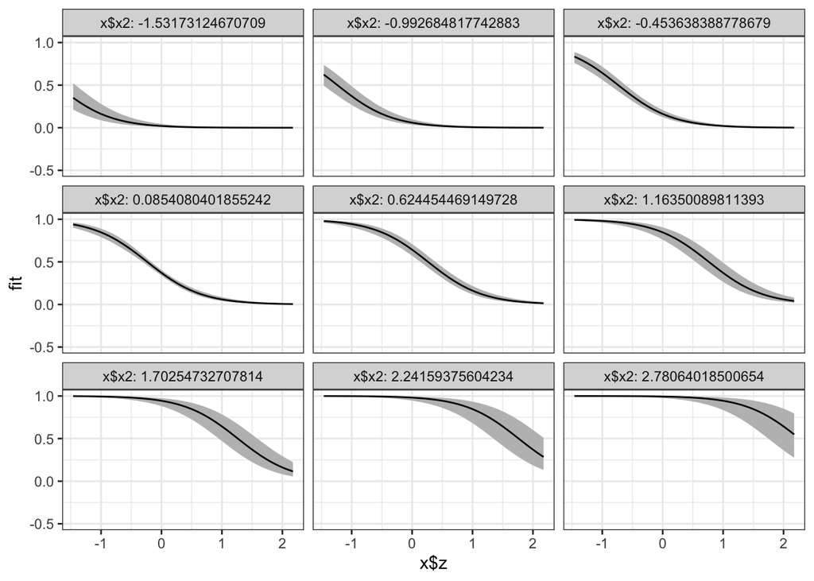

```r
mod4_predictions_with_bounds %>%
  ggplot(mapping = aes(x = x$z)) +
  geom_ribbon(mapping = aes(ymin = lwr, ymax = upr),
              fill = 'grey') +
  geom_line(mapping = aes(y = fit),
            color = 'black') +
  coord_cartesian(ylim = c(-.5, 1)) +
  facet_wrap(~x$x2, labeller = "label_both") +
  theme_bw()
```

# Mod 7

For model 7, the 2 most important inputs are w and x2, thus we will use those to populate our visualization grid.

```r
expand_grid <- expand.grid(x1 = median(df_derived$x1),  #values between 0 and 1
                        x2 = seq(min(df_derived$x2),max(df_derived$x2),length.out = 9),
                        x3 = median(df_derived$x3),
                        x4 = median(df_derived$x4),
                        m = unique(df$m),
                        v1 = median(df_derived$v1),
                        v2 = median(df_derived$v2),
                        v3 = median(df_derived$v3),
                        v4 = median(df_derived$v4),
                        v5 = median(df_derived$v5),
                        output = 1,
                        z = median(df_derived$z),
                         w = seq(min(df_derived$w),max(df_derived$w),length.out = 50),
                         t = median(df_derived$t),
                         x5 = median(df_derived$x5),
                        KEEP.OUT.ATTRS = FALSE,
                        stringsAsFactors = FALSE) %>%
  as.data.frame() %>% tibble::as_tibble()
```

Now that we have this synthetic data, we can make predictions to view the trends produced by our linear model.

```r
mod7_predictions <- predict(lin_mod7, newdata =expand_grid,
                         type = 'link', se.fit = TRUE)
```

```r
mod7_predictions_with_bounds <- tibble::tibble(
  x = expand_grid,
  fit = predict(lin_mod7, newdata = expand_grid, type = 'response'),
  lwr = lin_mod7$family$linkinv(mod7_predictions$fit - 1.96 * mod7_predictions$se.fit),
  upr = lin_mod7$family$linkinv(mod7_predictions$fit + 1.96 * mod7_predictions$se.fit)
)
```

And with these predictions we can visualize the predicted mean and confidence intervals.

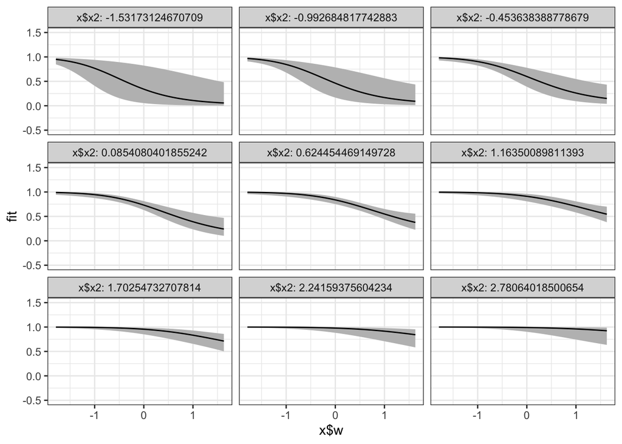

```r
mod7_predictions_with_bounds %>%
  ggplot(mapping = aes(x = x$w)) +
  geom_ribbon(mapping = aes(ymin = lwr, ymax = upr),
              fill = 'grey') +
  geom_line(mapping = aes(y = fit),
            color = 'black') +
  coord_cartesian(ylim = c(-.5, 1.5)) +
  facet_wrap(~x$x2, labeller = "label_both") +
  theme_bw()
```

# Comparing the Models

Looking at the two models, we can see that the predictive trends are very consistent between the two models. This likely has to do with the many shared terms between the two models.

## Train and tune with resampling

To train and tune our models, I will use the caret package.

```r
library(caret)
```

We will use a resampling scheme with 5 folds and 5 repeats. Our primary performance metric will be Accuracy

```r
my_ctrl <- trainControl(method = 'repeatedcv', number = 5, repeats = 5, classProbs = TRUE)

my_metric <- "Accuracy"
```

# Linear Models

First we will tune four linear models.

Model 1: Additive features using the “base feature” set

```r
set.seed(15217)
caret_linear_mod1 <- train(binary_outcome ~ x1 + x2 + x3 + x4 + v1 + v2 +v3 + v4 + v5,
                           data = df_derived,
                           method = 'glm',
                           metric = my_metric,
                            preProcess = c("center", "scale"),
                           trControl = my_ctrl)
```

Model 2: Additive features using the “expanded feature” set

```r
set.seed(15217)
caret_linear_mod2 <- train(binary_outcome ~ x5 + t + z + w + v3 + v4 + v5,
                           data = df_derived,
                           method = 'glm',
                           metric = my_metric,
                            preProcess = c("center", "scale"),
                           trControl = my_ctrl)
```

Model 3: Model 4 from the previous section

```r
set.seed(15217)
caret_linear_mod3 <- train(binary_outcome ~ . - m - output  -x5,
                           data = df_derived,
                           method = 'glm',
                           metric = my_metric,
                            preProcess = c("center", "scale"),
                           trControl = my_ctrl)
```

Model 4: Model 7 from the previous section

```r
set.seed(15217)
caret_linear_mod4 <- train(binary_outcome ~ x1 + x2 + x3 + x4 + v1 + v2 + v3 + v4 + v5 + w + z + t + I(x1^2) + I(x2^2) + I(x3^2) + I(x4^2) + I(v1^2) + I(v2^2) + I(v3^2) + I(v4^2) + I(v5^2) + I(w^2) + I(z^2) + I(t^2),
                           data = df_derived,
                           method = 'glm',
                           metric = my_metric,
                            preProcess = c("center", "scale"),
                           trControl = my_ctrl)
```

# Regularized regression with Elastic net

Model 5: Interact the categorical variable with all pair-wise interactions of the continuous features

```r
#t and x5 are excluded, x5 because it is a simple combination of x1-4 and t because it is simply v1:v2 and included in the model regardless.
set.seed(15217)
caret_elastic_mod5 <- train(binary_outcome ~  m * ( (x1 + x2 + x3 + x4 + v1 + v2 + v3 + v4 + v5 + z + w)*(x1 + x2 + x3 + x4 + v1 + v2 + v3 + v4 + v5 + z + w) ),
                           data = df_derived,
                           method = 'glmnet',
                           metric = my_metric,
                            preProcess = c("center", "scale"),
                           trControl = my_ctrl)
```

Model 6: Model 7 from the previous section

```r
set.seed(15217)
caret_elastic_mod6 <- train(binary_outcome ~ x1 + x2 + x3 + x4 + v1 + v2 + v3 + v4 + v5 + w + z + t + I(x1^2) + I(x2^2) + I(x3^2) + I(x4^2) + I(v1^2) + I(v2^2) + I(v3^2) + I(v4^2) + I(v5^2) + I(w^2) + I(z^2) + I(t^2),
                           data = df_derived,
                           method = 'glmnet',
                           metric = my_metric,
                            preProcess = c("center", "scale"),
                           trControl = my_ctrl)
```

# Neural Network

Model 7: Base Features

```r
set.seed(15217)
caret_neural_mod7  <- train(binary_outcome ~ x1 + x2 + x3 + x4 + v1 + v2 + v3 + v4 + v5 + m,
                           data = df_derived,
                           method = 'nnet',
                           metric = my_metric,
                            preProcess = c("center", "scale"),
                           trControl = my_ctrl,
                           trace = FALSE)
```

Model 8: Expanded Features

```r
set.seed(15217)
caret_neural_mod8  <- train(binary_outcome ~ x5 + t + z + w + v3 + v4 + v5 + m,
                           data = df_derived,
                           method = 'nnet',
                           metric = my_metric,
                            preProcess = c("center", "scale"),
                           trControl = my_ctrl,
                           trace = FALSE)
```

# Random Forest

Model 9: Base Set

```r
set.seed(15217)
caret_forest_mod9 <- train(binary_outcome ~ x1 + x2 + x3 + x4 + v1 + v2 + v3 + v4 + v5 + m,
                           data = df_derived,
                           method = 'rf',
                           metric = my_metric,
                           trControl = my_ctrl,
                           importance = TRUE)
```

Model 10: Expanded Features

```r
set.seed(15217)
caret_forest_mod10 <- train(binary_outcome ~ x5 + t + z + w + v3 + v4 + v5 + m,
                           data = df_derived,
                           method = 'rf',
                           metric = my_metric,
                           trControl = my_ctrl,
                           importance = TRUE)
```

# Gradient Boosted Tree

Model 11: Base Features

```r
set.seed(15217)
caret_boosted_mod11 <- train(binary_outcome ~ x1 + x2 + x3 + x4 + v1 + v2 + v3 + v4 + v5 + m,
                           data = df_derived,
                           method = 'xgbTree',
                           metric = my_metric,
                           trControl = my_ctrl,
                           verbosity = 0)
```

Model 12: Expanded Features

```r
set.seed(15217)
caret_boosted_mod12 <- train(binary_outcome ~ x5 + t + z + w + v3 + v4 + v5 + m,
                           data = df_derived,
                           method = 'xgbTree',
                           metric = my_metric,
                           trControl = my_ctrl,
                           verbosity = 0)
```

# Two additional methods

Model 13: Partial Least Squares using the base features

```r
pls_grid <- expand.grid(ncomp = 1:5)
set.seed(15217)
caret_pls_mod13 <- train(binary_outcome ~ x1 + x2 + x3 + x4 + v1 + v2 + v3 + v4 + v5 + m,
                 data = df_derived,
                 method = "pls",
                 metric = my_metric,
                 tuneGrid = pls_grid,
                 preProcess = c("center", "scale"),
                 trControl = my_ctrl)
```

Model 14:Support Vector Machines using the base features

```r
set.seed(15217)
caret_svm_mod14 <- train(binary_outcome ~ x1 + x2 + x3 + x4 + v1 + v2 + v3 + v4 + v5 + m,
                 data = df_derived,
                 method = "svmRadial",
                 metric = my_metric,
                 preProcess = c("center", "scale"),
                 trControl = my_ctrl)
```

# Best Model

To help us select a best model, we will compare them using a dot plot.

```r
caret_compare <- resamples(list(Model_1 = caret_linear_mod1,
                                Model_2 = caret_linear_mod2,
                                Model_3 = caret_linear_mod3,
                                Model_4 = caret_linear_mod4,
                                Model_5 = caret_elastic_mod5,
                                Model_6 = caret_elastic_mod6,
                                Model_7 = caret_neural_mod7,
                                Model_8 = caret_neural_mod8,
                                Model_9 = caret_forest_mod9,
                                Model_10 = caret_forest_mod10,
                                Model_11 = caret_boosted_mod11,
                                Model_12 = caret_boosted_mod12,
                                Model_13 = caret_pls_mod13,
                                Model_14 = caret_svm_mod14
                                ))
```

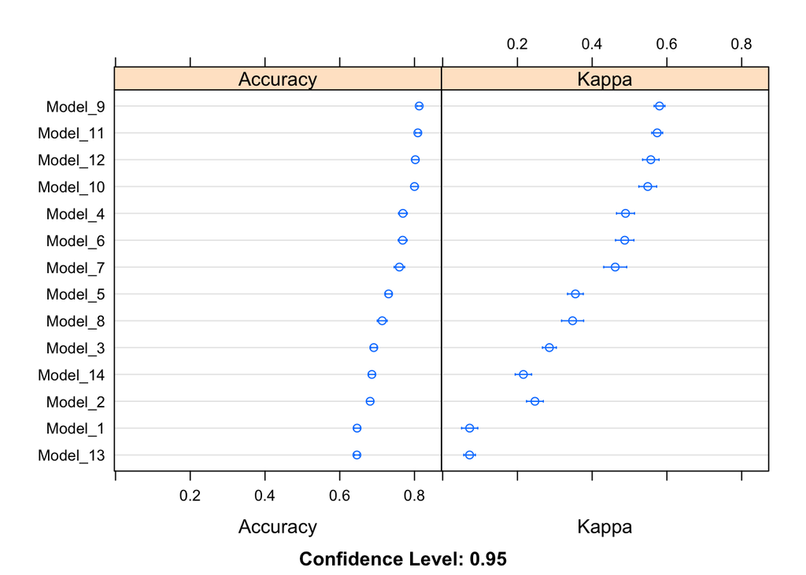

```r
dotplot(caret_compare)
```

Looking at both the accuracy and kappa values for each model, we can see that model 9 has the best performance by both metrics and is our overall best model. Model 9 is also the best model for the ROC metric, but those trained models are not included in this writeup as Accuracy is the metric I am using to x my models.